# practical4

```r
#this line represents the predicted medv values for lstat
```

11.The interval argument can be used to generate confidence or prediction intervals. Create a new object called y_pred_95 using predict() (again with the pred_dat data) with the interval argument set to “confidence”. What is in this object?

```r
y_pred_95<-predict(lm_ses,newdata = pred_dat, interval= "confidence")

head(y_pred_95)
```

```
##        fit      lwr      upr
## 1 34.55384 33.44846 35.65922
## 2 34.51580 33.41307 35.61853
## 3 34.47776 33.37768 35.57784
## 4 34.43972 33.34229 35.53715
## 5 34.40168 33.30690 35.49646
## 6 34.36364 33.27150 35.45578
```

```r
class(y_pred_95)
```

```
## [1] "matrix" "array"
```

```r
#its a matrix with upper and lower confidence intervals for the fitted values
```

12.Create a data frame with 4 columns: medv, lstat, lower, and upper.

```r
y_pred_95<-as.data.frame(y_pred_95)
df_with_confidence<-data.frame(medv=pred_dat$medv, lstat= pred_dat$lstat, lower=y_pred_95$lwr, upper=y_pred_95$upr)
```

13.Add a geom_ribbon() to the plot with the data frame you just made. The ribbon geom requires three aesthetics: x (lstat, already mapped), ymin (lower), and ymax (upper). Add the ribbon below the geom_line() and the geom_points() of before to make sure those remain visible. Give it a nice colour and clean up the plot, too!

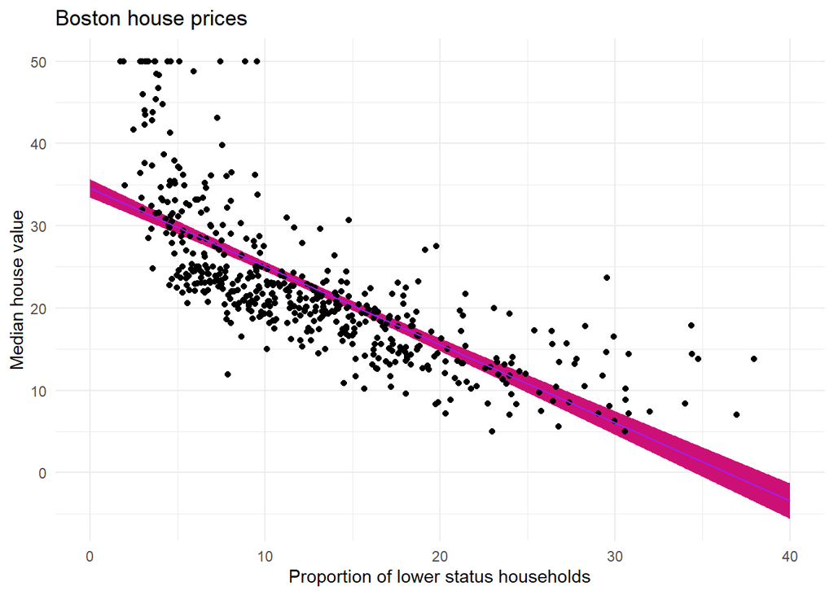

```r
ggplot() +geom_ribbon(data=df_with_confidence,aes(x=lstat,ymin=lower,ymax=upper), fill="deeppink3")+geom_point(data = Boston, aes(x=lstat,y=medv))+geom_line(data=pred_dat, aes(x=lstat, y=medv), colour="purple") +theme_minimal()+ labs(x    = "Proportion of lower status households",y    = "Median house value", title = "Boston house prices")
```

14.Explain in your own words what the ribbon represents.

```r
#the ribbon represents the 95% confidence intervals of the fitted values
```

15.Do the same thing, but now with the prediction interval instead of the confidence interval.

```r
y_pred_95_2<-predict(lm_ses,newdata = pred_dat, interval= "prediction")

head(y_pred_95_2)
```

```
##        fit      lwr      upr
## 1 34.55384 22.29192 46.81576
## 2 34.51580 22.25412 46.77748
## 3 34.47776 22.21632 46.73920
## 4 34.43972 22.17852 46.70092
## 5 34.40168 22.14071 46.66265
## 6 34.36364 22.10291 46.62437
```

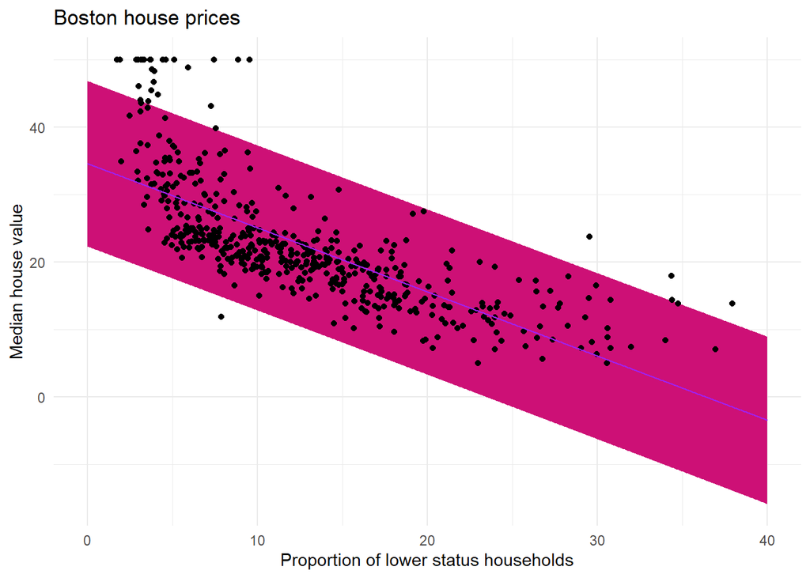

```r
y_pred_95_2<-as.data.frame(y_pred_95_2)
df_with_prediction<-data.frame(medv=pred_dat$medv, lstat= pred_dat$lstat, lower=y_pred_95_2$lwr, upper=y_pred_95_2$upr)

ggplot() +geom_ribbon(data=df_with_prediction,aes(x=lstat,ymin=lower,ymax=upper), fill="deeppink3")+geom_point(data = Boston, aes(x=lstat,y=medv))+geom_line(data=pred_dat, aes(x=lstat, y=medv), colour="purple") +theme_minimal()+ labs(x    = "Proportion of lower status households",y    = "Median house value", title = "Boston house prices")
```

```r
#the prediction intervals are always bigger than the confidence intervals (because they are for one observation)
```

##Mean square error 16.Write a function called mse() that takes in two vectors: true y values and predicted y values, and which outputs the mean square error.

```r
mse <- function(y_true, y_pred) {
  mean((y_true - y_pred)^2)
}
```

17.Make sure your mse() function works correctly by running the following code.

```r
mse(1:10, 10:1)
```

```
## [1] 33
```

18.Calculate the mean square error of the lm_ses model. Use the medv column as y_true and use the predict() method to generate y_pred.

```r
mse(Boston$medv,predict(lm_ses))
```

```
## [1] 38.48297
```

##Train-validation-test split